# hw06

ziqiangt

2018/11/05

## Introduction

This is the first assignment of STAT 547M (despite it being named Homework 06).

First, let’s load the used data

```r
suppressPackageStartupMessages(library(gapminder))
suppressPackageStartupMessages(library(tidyverse))
suppressPackageStartupMessages(library(stringr))
suppressPackageStartupMessages(library(testthat))
suppressPackageStartupMessages(library(stringi))
suppressPackageStartupMessages(library(ggplot2))
```

## 1.Character data

### 14.2.5 Exercises

#### Q1

In code that doesn’t use stringr, you’ll often see paste() and paste0(). What’s the difference between the two functions? Answer: paste() allows us to add an separator between strings while paste0() dose not. Here is an example:

```r
paste("Task", "1", sep = "-")
```

```
## [1] "Task-1"
```

```r
paste0("Task", "1")
```

```
## [1] "Task1"
```

What stringr function are they equivalent to? How do the functions differ in their handling of NA? Answer: paste() and paste0() equivalent to str_c(). Here is an example:

```r
str_c("Task", "1", sep = "-")
```

```
## [1] "Task-1"
```

```r
str_c("Task", "1", sep = "")
```

```
## [1] "Task1"
```

How do the functions differ in their handling of NA? Answer: NA is converted to a string “NA” in paste() and paste0(). However, if NA is one of the input strings for str_c(), the output of str_c() will be NA. Here is an example:

```r
paste("Look ", NA, sep = "")
```

```
## [1] "Look NA"
```

```r
paste0("Look ", NA)
```

```
## [1] "Look NA"
```

```r
str_c("Look ", NA)
```

```
## [1] NA
```

#### Q2

In your own words, describe the difference between the sep and collapse arguments to str_c(). Answer:“sep” is used to seperate a vector of strings and keep the vector format. While “collapse” to a vector of strings into a single string. Here is an example:

```r
str_c(c("x", "y", "z"), c("a", "b", "c"), sep = ": ")
```

```
## [1] "x: a" "y: b" "z: c"
```

```r
str_c(c("x", "y", "z"), c("a", "b", "c"), collapse = ":")
```

```
## [1] "xa:yb:zc"
```

#### Q3

Use str_length() and str_sub() to extract the middle character from a string. What will you do if the string has an even number of characters? Answer:First, we need to use str_length to obtain the middle index. Then use str_sub to output the middle character. Here is the example:

```r
odd_string <- "eye"

# A function to find the middle index
find_middle <- function(input) {
  return(str_length(input) / 2 + 1)
}

# Obtain the middle index and output the midelle character
odd_index <- find_middle(odd_string)
str_sub(odd_string, odd_index, odd_index)
```

```
## [1] "y"
```

What will you do if the string has an even number of characters? Answer: We need to modify the str_sub. Because there are two middle characters now. Here is an modified example:

```r
even_string <- "eyne"

# A function to find the middle index
find_middle_even <- function(input) {
  return(str_length(input) / 2 + 1 )
}

# Obtain the middle index and output the midelle character
even_index <- find_middle_even(even_string)
str_sub(even_string, even_index-1, even_index)
```

```
## [1] "yn"
```

#### Q4

What does str_wrap() do? When might you want to use it? Answer: str_wrap() tries to implement the Knuth-Plass paragraph wrapping algorithm. It might be used when we need to sperate a long paragraph into multiple lines. Here is an example:

```r
# a long sentence
paragraph <- "One or more elements are missing or sketchy. Missed opportunities to complement code and numbers with a figure and interpretation. Technical problem that is relatively easy to fix. It’s hard to find the report in this crazy repo."

# view without wrap
cat(paragraph)
```

```
## One or more elements are missing or sketchy. Missed opportunities to complement code and numbers with a figure and interpretation. Technical problem that is relatively easy to fix. It’s hard to find the report in this crazy repo.
```

```r
# view with wrap
cat(str_wrap(paragraph), sep = "\n")
```

```
## One or more elements are missing or sketchy. Missed opportunities to complement
## code and numbers with a figure and interpretation. Technical problem that is
## relatively easy to fix. It’s hard to find the report in this crazy repo.
```

#### Q5

What does str_trim() do? Answer: str_trim() removes whitespace from start and end of string.

```r
# before removing whitespace from start and end of string
spaces_string = "  I am  "
spaces_string
```

```
## [1] "  I am  "
```

```r
# After using str_trim()
no_spaces_string <- str_trim(spaces_string)
no_spaces_string
```

```
## [1] "I am"
```

What’s the opposite of str_trim()? Answer: The opposite is str_pad() which is used to add whitespace. Here is an example to combine neighborhood character of letters.

```r
letters %>%
  .[1:10] %>%
  str_pad(width = 2, side = "right") %>%
  str_c(letters[2:11])
```

```
##  [1] "a b" "b c" "c d" "d e" "e f" "f g" "g h" "h i" "i j" "j k"
```

Write a function that turns (e.g.) a vector c(“a”, “b”, “c”) into the string a, b, and c. Think carefully about what it should do if given a vector of length 0, 1, or 2.

```r
vector_to_string <- function(v) {
  if (length(v) == 0){
    return("")
  }
  else if (length(v) == 1){
    return(v)
  }
  else{
    front <- str_c(v[-length(v)], collapse = ", ")
    whole <- str_c(front, v[length(v)], sep = " and ")
    return(whole)
  }
}

#begin to test
vector_to_string(c(""))
```

```
## [1] ""
```

```r
vector_to_string(c("a"))
```

```
## [1] "a"
```

```r
vector_to_string(c("a", "b"))
```

```
## [1] "a and b"
```

```r
vector_to_string(c("a", "b","c"))
```

```
## [1] "a, b and c"
```

### 14.3.1.1 Exercises

#### Q1

Explain why each of these strings don’t match a : “",”\“,”\"?

| symbol | Definition |
| --- | --- |
| `\` | used as an escape character in regular expressions |
| `\\` | trated as a symbol “" |
| `\\\` | a back slash + an escape character |

Here is an example:

```r
test <- "I\\AM"
str_view(test, pattern = "\\\\", match = TRUE)
```

[interactive chart not shown]

#### Q2

How would you match the sequence “‘? Answer: Both’ and need to be escaped in regex.

```r
test <- "\"'\\AM"
test
```

```
## [1] "\"'\\AM"
```

```r
str_view(test, pattern = "\"\\'\\\\", match = TRUE)
```

[interactive chart not shown]

#### Q3

What patterns will the regular expression ...... match? How would you represent it as a string? Answer: It match “.anycharacter.anycharacter.anycharacter”

```r
test <- "I.A.M.z...xxx"

str_view(test, pattern = "\\..\\..\\..", match = TRUE)
```

[interactive chart not shown]

### 14.3.2.1 Exercises

#### Q1

How would you match the literal string “$^$”? Answer: Both $ and ^ need to be escaped in regex.

```r
test <- "$^$, $$sssa"
str_view(test, pattern = "\\$\\^\\ $", match = TRUE)
```

[interactive chart not shown]

#### Q2

Given the corpus of common words in stringr::words, create regular expressions that find all words that:

Start with “y”.

```r
str_view(stringr::words, pattern = "^y", match = TRUE)
```

[interactive chart not shown]

End with “x”.

```r
str_view(stringr::words, pattern = "x$", match = TRUE)
```

[interactive chart not shown]

Are exactly three letters long. (Don’t cheat by using str_length()!)

```r
#There are too many matched words
#let's narrow down the search range to the head 20 words
str_view(stringr::words[1:20], pattern = "^.{3}$", match = TRUE)
```

[interactive chart not shown]

Have seven letters or more.

```r
#There are too many matched words
#let's narrow down the search range to the head 20 words
str_view(stringr::words[1:20], pattern = "^.{7,}$", match = TRUE)
```

[interactive chart not shown]

### 14.3.3.1 Exercises

#### Q1

Create regular expressions to find all words that:

Start with a vowel.

```r
str_view(stringr::words, pattern = "^[aeiou]|[AEIOU]", match = TRUE)
```

[interactive chart not shown]

That only contain consonants.

```r
str_view(stringr::words, pattern = "^[^aeiou]{1,}$", match = TRUE)
```

[interactive chart not shown]

End with ed, but not with eed.

```r
str_view(stringr::words, pattern = "[^e]e{1}d$", match = TRUE)
```

[interactive chart not shown]

End with ing or ise.

```r
str_view(stringr::words, pattern = "ing|ise$", match = TRUE)
```

[interactive chart not shown]

#### Q2

Empirically verify the rule “i before e except after c”.

```r
# Rule “i before e except after c
high_subset <- str_subset(stringr::words, pattern = "[^c]ie|cei")
high_subset %>% knitr::kable()
```

| x |
| --- |
| achieve |
| believe |
| brief |
| client |
| die |
| experience |
| field |
| friend |
| lie |
| piece |
| quiet |
| receive |
| tie |
| view |

```r
# The one which obey the rule
low_subset <- str_subset(stringr::words, pattern = "cie|[^c]ei")
low_subset %>% knitr::kable()
```

| x |
| --- |
| science |
| society |
| weigh |

```r
# Test
if(length(high_subset) > length(low_subset))
  "Rule is correct"
```

```
## [1] "Rule is correct"
```

s “q” always followed by a “u”?

```r
#Find the words q is not followed by u
q_followed_u <- str_subset(stringr::words, pattern = "q[^u]")

#Test
test_that("“q” always followed by a “u”", {
  expect_more_than(1, length(q_followed_u))
})
```

Answer: Test passed

#### Q3

Write a regular expression that matches a word if it’s probably written in British English, not American English. Answer: According to [oxfordinternationalenglish](https://www.oxfordinternationalenglish.com/differences-in-british-and-american-spelling/),British English words ending in ‘our’ usually end in ‘or’ in American English. Here is an example:

```r
# Test vectors
test_words <- c("colour", "flavor", "humour", "labor", "neighbour")

# View results
str_view(test_words, pattern = "our", match = TRUE)
```

[interactive chart not shown]

#### Q4

Create a regular expression that will match telephone numbers as commonly written in your country. Answer: In my country, China, the telephone number starts with +86 and have 11 digits (except +86) in total.

```r
# Test vectors
test_words <- c("+8613777705661", "+16044888876", "+1605888876", "+861377770566")

# View results
str_view(test_words, pattern = "^\\+86[0-9]{11}", match = TRUE)
```

[interactive chart not shown]

### 14.3.4.1 Exercises

#### Q1

Describe the equivalents of ?, +, * in {m,n} form. Answer:

| symbol | equivalent |
| --- | --- |
| `?` | {0,1} |
| `+` | {1,} |
| `*` | {0,} |

#### Q2

Describe in words what these regular expressions match: (read carefully to see if I’m using a regular expression or a string that defines a regular expression.)

| symbol | match |
| --- | --- |
| `^.*$` | any strings |
| `\\{.+\\}` | {at least one character} for example: {a}, {abd} |
| `\d{4}-\d{2}-\d{2}` | matches in the format dddd-dd-dd, where d is digit. For example, “1111-22-33”. |
| ‘\\{4}’ | matches four back slashes |

#### Q3

Create regular expressions to find all words that: Start with three consonants.

```r
str_view(stringr::words, pattern = "^[^aeoiu]{3,}", match = TRUE)
```

[interactive chart not shown]

Have three or more vowels in a row.

```r
str_view(stringr::words, pattern = "[aeoiu]{3,}", match = TRUE)
```

[interactive chart not shown]

```r
str_view(stringr::words, pattern = "([aeoiu][^aeoiu]){3,}", match = TRUE)
```

[interactive chart not shown]

#### Q4

Solve the beginner regexp crosswords at [this link](https://regexcrossword.com/challenges/beginner).

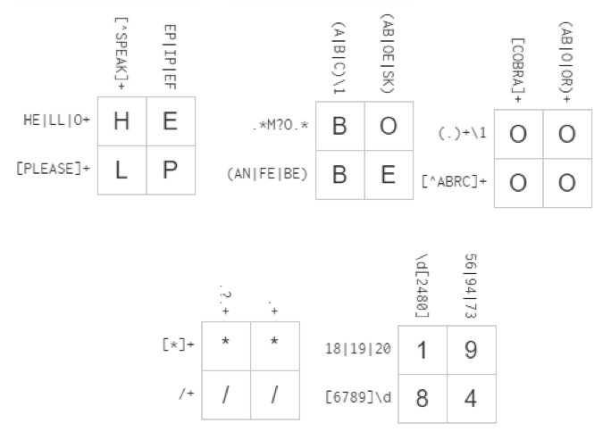

### 14.3.5.1 Exercises

#### Q1

Describe, in words, what these expressions will match:

| symbol | match |
| --- | --- |
| (.) | match a character followed with . e.g. “x” |
| “(.)(.)\2\1” | match the two characters followed with and reversal. e.g. “xyyx” |
| `(..)\1` | match a pair of characters followed with . e.g. “ab” |
| “(.).\1.\1” | match in the format “x anycharacter x anycharacter x”. e.g. “abaxa” |
| “(.)(.)(.).*\3\2\1“ | match three characters appears at the beginning, then follows by any characters (0 or more), then the reversal of the begining three characters. For example, “abcxxcba”. |

#### Q2

Construct regular expressions to match words that: Start and end with the same character.

```r
str_view(stringr::words, pattern = "^(.).*\\1$", match = TRUE)
```

[interactive chart not shown]

Contain a repeated pair of letters (e.g. “church” contains “ch” repeated twice.)

```r
str_view(stringr::words, pattern = "(..).*\\1", match = TRUE)
```

[interactive chart not shown]

Contain one letter repeated in at least three places (e.g. “eleven” contains three “e”s.)

```r
str_view(stringr::words, pattern = "(.).*\\1.*\\1", match = TRUE)
```

[interactive chart not shown]

### 14.4.2 Exercises

#### Q1

For each of the following challenges, try solving it by using both a single regular expression, and a combination of multiple str_detect() calls.

Find all words that start or end with x.

```r
# single regular expression
str_subset(stringr::words, pattern = "^x|x$") %>%
  knitr::kable(col.names = c("Single Regular Expression"))
```

| Single Regular Expression |
| --- |
| box |
| sex |
| six |
| tax |

```r
# multiple str_detect()
m1 <- str_detect(stringr::words, pattern = "^x")
m2 <- str_detect(stringr::words, pattern = "x$")

## show table
stringr::words %>%
  `[`(m1 | m2) %>%
  knitr::kable(col.names = c("Multiple str_detect()"))
```

| Multiple str_detect() |
| --- |
| box |
| sex |
| six |
| tax |

Find all words that start with a vowel and end with a consonant.

```r
# single regular expression, here we just search first 10 rows
str_subset(stringr::words[1:10], pattern = "^[aeiou].*[^aeiou]$") %>%
  knitr::kable(col.names = c("Single Regular Expression"))
```

| Single Regular Expression |
| --- |
| about |
| accept |
| account |
| across |
| act |

```r
# multiple str_detect(), here we just search first 10 rows
m1 <- str_detect(stringr::words[1:10], pattern = "^[aeiou].*")
m2 <- str_detect(stringr::words[1:10], pattern = "[^aeiou]$")

## show table
stringr::words[1:10] %>%
  `[`(m1 & m2) %>%
  knitr::kable(col.names = c("Multiple str_detect()"))
```

| Multiple str_detect() |
| --- |
| about |
| accept |
| account |
| across |
| act |

Are there any words that contain at least one of each different vowel? Answer: In orer to use single regular expression, we need to wirte 5*4*3*2*1=120 conditions. For example, we need to match “abc”" disorderly. There are 6 conditions: abc, acd, bac, bca, cab, cba. It is therefore seems impossible to use a single regular expression to finish this question. However, we could use “?=” which is a positive lookahead, a type of zero-width assertion to solve this problem.

```r
test_words <- c("eioua", "aaaaa", "abcde", "aeeiuuo", "eeeiuuuuo")

# single regular expression
str_subset(test_words, pattern = "(?=.*a.*)(?=.*e.*)(?=.*i.*)(?=.*o.*)(?=.*u.*)") %>%
  knitr::kable(col.names = c("Single Regular Expression"))
```

| Single Regular Expression |
| --- |
| eioua |
| aeeiuuo |

```r
# multiple str_detect()
m1 <- str_detect(test_words, pattern = "(?=.*a.*)")
m2 <- str_detect(test_words, pattern = "(?=.*e.*)")
m3 <- str_detect(test_words, pattern = "(?=.*i.*)")
m4 <- str_detect(test_words, pattern = "(?=.*o.*)")
m5 <- str_detect(test_words, pattern = "(?=.*u.*)")

## show table
test_words %>%
  `[`(m1 & m2 & m3 & m4 & m5) %>%
  knitr::kable(col.names = c("Multiple str_detect()"))
```

| Multiple str_detect() |
| --- |
| eioua |
| aeeiuuo |

#### Q2

What word has the highest number of vowels?

```r
# The highest number of vowels
max(str_count(stringr::words, "[aeiou]")) %>%
  knitr::kable(col.names = c("Highest Number of Vowelss"))
```

| Highest Number of Vowelss |
| --- |
| 5 |

```r
# find the words with the highest number of vowels
num_vowels <- str_count(stringr::words, "[aeiou]")

stringr::words %>%
  `[`(num_vowels == max(num_vowels)) %>%
  knitr::kable(col.names = c("Detected Words"))
```

| Detected Words |
| --- |
| appropriate |
| associate |
| available |
| colleague |
| encourage |
| experience |
| individual |
| television |

What word has the highest proportion of vowels? (Hint: what is the denominator?)

```r
#  find highest proportion of vowels
portion_vowels <- str_count(stringr::words, "[aeiou]")/str_length(stringr::words)

stringr::words %>%
  `[`(portion_vowels == max(portion_vowels)) %>%
  knitr::kable(col.names = c("Detected Words"))
```

| Detected Words |
| --- |
| a |

### 14.4.3.1 Exercises

#### Q1

In the previous example, you might have noticed that the regular expression matched “flickered”, which is not a colour. Modify the regex to fix the problem.

```r
# Example in book
colours <- c("red", "orange", "yellow", "green", "blue", "purple")
colour_match <- str_c(colours, collapse = "|")
colour_match
```

```
## [1] "red|orange|yellow|green|blue|purple"
```

```r
more <- sentences[str_count(sentences, colour_match) > 1]
str_view_all(more, colour_match)
```

[interactive chart not shown]

It can been seen that flickered is also be matched. Thus, we need to define the word boundary. Here is the modifed one:

```r
boundary_colour_match <- str_c("\\b", colour_match, "\\b")

modified <- sentences[str_count(sentences, boundary_colour_match) > 1]
str_view_all(modified, colour_match)
```

[interactive chart not shown]

#### Q2

From the Harvard sentences data, extract: The first word from each sentence.

```r
first_words <- str_extract(sentences[1:10], pattern = "[a-zA-Z']+")

tibble(sentences[1:10], first_words) %>%
  knitr::kable(col.names = c("Selected Sentences", "First Word"))
```

| Selected Sentences | First Word |
| --- | --- |
| The birch canoe slid on the smooth planks. | The |
| Glue the sheet to the dark blue background. | Glue |
| It’s easy to tell the depth of a well. | It’s |
| These days a chicken leg is a rare dish. | These |
| Rice is often served in round bowls. | Rice |
| The juice of lemons makes fine punch. | The |
| The box was thrown beside the parked truck. | The |
| The hogs were fed chopped corn and garbage. | The |
| Four hours of steady work faced us. | Four |
| Large size in stockings is hard to sell. | Large |

All words ending in ing.

```r
str_view(sentences, pattern = "[A-Za-z]+ing\\b", match = TRUE)
```

[interactive chart not shown]

All plurals.

```r
# Just match the first 10 rows
str_view(sentences[1:10], pattern = "\\b[A-Za-z]{3,}e{0,1}s{1}\\b", match = TRUE)
```

[interactive chart not shown]

### 14.4.4.1 Exercises

#### Q1

Find all words that come after a “number” like “one”, “two”, “three” etc. Pull out both the number and the word.

```r
# we assume we just have 0-10 number
numbers = c("zero","one","two","three","four","five","six","seven","eight","nine",
         "ten")

# collapse all nums using "|""
pattern <- str_c(numbers, collapse = "|")

# redesign the pattern to find the after word
pattern <- str_c(" (", pattern, ") ([a-zA-Z])+ ")

str_view(sentences[1:100], pattern = pattern, match = TRUE)
```

[interactive chart not shown]

#### Q2

Find all contractions. Separate out the pieces before and after the apostrophe.

```r
# Find the sentences meeting the requirement
pattern <- str_c("([a-zA-Z])+", "'", "([a-zA-Z])+")
filter_sentences <- sentences[str_detect(sentences, pattern = pattern)]

# Keep the  the pieces before and after the apostrophe part and remove '
contractions <- str_extract_all(filter_sentences, pattern = pattern, simplify = TRUE)
pieces <- str_split(contractions, pattern = "'", simplify = TRUE)

# show results as a table
data.frame(filter_sentences, pieces) %>%
 knitr::kable(col.names = c("Sentences with Contractions", "Before Apostrophe", "After Apostrophe"))
```

| Sentences with Contractions | Before Apostrophe | After Apostrophe |
| --- | --- | --- |
| It’s easy to tell the depth of a well. | It | s |
| The soft cushion broke the man’s fall. | man | s |
| Open the crate but don’t break the glass. | don | t |
| Add the store’s account to the last cent. | store | s |
| The beam dropped down on the workmen’s head. | workmen | s |
| Let’s all join as we sing the last chorus. | Let | s |
| The copper bowl shone in the sun’s rays. | sun | s |
| A child’s wit saved the day for us. | child | s |
| A ripe plum is fit for a king’s palate. | king | s |
| It’s a dense crowd in two distinct ways. | It | s |
| We don’t get much money but we have fun. | don | t |
| Ripe pears are fit for a queen’s table. | queen | s |
| We don’t like to admit our small faults. | don | t |
| Dig deep in the earth for pirate’s gold. | pirate | s |
| She saw a cat in the neighbor’s house. | neighbor | s |

### 14.4.5.1 Exercises

#### Q1

Replace all forward slashes in a string with backslashes.

```r
test_strings <- c("I/AM", "It/OK") %>%
  str_replace("/", "\\\\")
test_strings
```

```
## [1] "I\\AM"  "It\\OK"
```

#### Q2

Implement a simple version of str_to_lower() using replace_all().

```r
test_strings <- c("I/AM", "It/OK") %>%
  str_replace_all( c("A"="a", "B"="b", "C"="c", "D"="d", "E"="e", "F"="f", "G"="g", "H"="h", "I"="i", "J"="j", "K"="k", "L"="l", "M"="m", "N"="n", "O"="o", "P"="p", "Q"="q", "R"="r", "S"="s", "T"="t", "U"="u", "V"="v", "W"="w", "X"="x", "Y"="y", "Z"="z"))

test_strings
```

```
## [1] "i/am"  "it/ok"
```

#### Q3

Switch the first and last letters in words.

```r
switch <- str_replace(stringr::words,
                      pattern = "([a-zA-Z])([a-zA-Z]*)([a-zA-Z]$)",
                      replacement = "\\3\\2\\1")

# show some of the words
switch %>%
  head(10) %>%
  knitr::kable(col.names = "Switch results")
```

| Switch results |
| --- |
| a |
| ebla |
| tboua |
| ebsoluta |
| tccepa |
| tccouna |
| echieva |
| scrosa |
| tca |
| ectiva |

Which of those strings are still words? Answer: We can use “intersect” to find two sets that they have in common.

```r
intersect(stringr::words, switch) %>%
  head(10) %>%
  knitr::kable(col.names = "Still Words")
```

| Still Words |
| --- |
| a |
| america |
| area |
| dad |
| dead |
| deal |
| dear |
| depend |
| dog |
| educate |

### 14.4.6.1 Exercises

#### Q1

Split up a string like “apples, pears, and bananas” into individual components.

```r
test_string <- c("apples, pears, and bananas")

# use str_split() with boundary(word)
str_split(test_string, boundary("word"))[[1]] %>%
  knitr::kable(col.names = c("Individual Components"))
```

| Individual Components |
| --- |
| apples |
| pears |
| and |
| bananas |

#### Q2

Why is it better to split up by boundary(“word”) than " “? Answer: Since use” " will bring other symbol rather a pure word. Here is an example.

```r
# create string to test
test_string <- c("apples, pears, and bananas")

# use str_split() with " "
str_split(test_string, " ")[[1]] %>%
   knitr::kable(col.names = c("Individual Components"))
```

| Individual Components |
| --- |
| apples, |
| pears, |
| and |
| bananas |

#### Q3

What does splitting with an empty string (“”) do? Experiment, and then read the documentation. Answer: It will split every single character. This is same as boundary(‘character’). Here is an example.

```r
# create string to test
test_string <- c("apples, pears, and bananas")

# use str_split() with " "
str_split(test_string, "")[[1]] %>%
   knitr::kable(col.names = c("Individual Components"))
```

| Individual Components |
| --- |
| a |
| p |
| p |
| l |
| e |
| s |
| , |
| p |
| e |
| a |
| r |
| s |
| , |
| a |
| n |
| d |
| b |
| a |
| n |
| a |
| n |
| a |
| s |

### 14.5.1 Exercises

#### Q1

How would you find all strings containing with regex() vs. with fixed()?

| symbol | match |
| --- | --- |
| with regex() | \\ |
| with fixed() | \ |

#### Q2

What are the five most common words in sentences?

```r
word_list <- sentences %>%
  # split all words from sentences
  str_split(boundary("word"), simplify = TRUE) %>%
  # change to lower case for futhure counting
  str_to_lower()

# Using tibble to count words and kable them
tibble(words = word_list) %>%
  count(words, sort = TRUE) %>%
  head(6) %>%
  knitr::kable(col.names = c("Top 5 Words", "Count"))
```

| Top 5 Words | Count |
| --- | --- |
|  | 2892 |
| the | 751 |
| a | 202 |
| of | 132 |
| to | 123 |
| and | 118 |